# Data Analysis Assignment

Nelson Corrocher

July 31, 2016

## Preparing the Environment

```r
v <- read.csv("LIWC2015 Results.csv")
library(ggplot2)
```

## Exploratory Analysis

### Generate basic statistics about the dataset using functions like “summary()”, execute “mean()” and “sd()” on the Wordcount and WPS columns

```
## Variables Summary:
```

```
##                Filename  DecadePublished YearPublished
##  1887-Dewey.txt    : 1   Min.   :1880    Min.   :1887
##  1891-Ladd.txt     : 1   1st Qu.:1910    1st Qu.:1919
##  1892-Davis.txt    : 1   Median :1940    Median :1947
##  1892-Jimmy.txt    : 1   Mean   :1940    Mean   :1945
##  1893-Baldwin.txt  : 1   3rd Qu.:1970    3rd Qu.:1974
##  1897-Scripture.txt: 1   Max.   :1990    Max.   :1997
##  (Other)           :60
##                Author         WC            Analytic         Clout
##  Angell           : 1   Min.   : 34496   Min.   :82.97   Min.   :39.39
##  Baldwin          : 1   1st Qu.:114816   1st Qu.:90.16   1st Qu.:54.43
##  Bartley          : 1   Median :180679   Median :92.33   Median :62.09
##  Boring et al     : 1   Mean   :183570   Mean   :91.96   Mean   :61.34
##  Bourne_&_Ekstrand: 1   3rd Qu.:227584   3rd Qu.:94.53   3rd Qu.:68.60
##  Calkins          : 1   Max.   :394580   Max.   :97.37   Max.   :78.44
##  (Other)          :60
##    Authentic          Tone            WPS            Sixltr
##  Min.   :18.19   Min.   :19.92   Min.   :14.16   Min.   :21.87
##  1st Qu.:23.91   1st Qu.:27.48   1st Qu.:18.14   1st Qu.:25.64
##  Median :28.04   Median :33.73   Median :19.75   Median :27.32
##  Mean   :28.35   Mean   :34.60   Mean   :20.25   Mean   :27.10
##  3rd Qu.:31.94   3rd Qu.:41.42   3rd Qu.:21.84   3rd Qu.:28.33
##  Max.   :48.25   Max.   :61.85   Max.   :28.92   Max.   :31.58
##
##       Dic          function.        pronoun           ppron
##  Min.   :77.30   Min.   :42.62   Min.   : 5.250   Min.   :1.440
##  1st Qu.:80.67   1st Qu.:46.92   1st Qu.: 7.537   1st Qu.:2.748
##  Median :82.03   Median :49.26   Median : 8.000   Median :3.295
##  Mean   :81.99   Mean   :49.11   Mean   : 8.218   Mean   :3.171
##  3rd Qu.:83.32   3rd Qu.:51.56   3rd Qu.: 9.043   3rd Qu.:3.610
##  Max.   :86.54   Max.   :55.00   Max.   :11.100   Max.   :6.090
##
##        i                we              you             shehe
##  Min.   :0.0100   Min.   :0.3000   Min.   :0.0000   Min.   :0.1300
##  1st Qu.:0.1200   1st Qu.:0.5875   1st Qu.:0.0525   1st Qu.:0.5225
##  Median :0.1700   Median :0.8500   Median :0.1300   Median :0.8100
##  Mean   :0.2398   Mean   :0.9714   Mean   :0.2998   Mean   :0.8409
##  3rd Qu.:0.3175   3rd Qu.:1.1525   3rd Qu.:0.4350   3rd Qu.:1.1175
##  Max.   :0.9600   Max.   :3.1900   Max.   :2.0700   Max.   :2.0600
##
```

[output cut: 145 more lines]

```
##  Min.   :0.00000   Min.   :0.0000   Min.   :0.0000   Min.   :0.0100
##  1st Qu.:0.00250   1st Qu.:0.4400   1st Qu.:0.0100   1st Qu.:0.1200
##  Median :0.01000   Median :0.5900   Median :0.0400   Median :0.1800
##  Mean   :0.01818   Mean   :0.5939   Mean   :0.2323   Mean   :0.2944
##  3rd Qu.:0.03000   3rd Qu.:0.7850   3rd Qu.:0.2750   3rd Qu.:0.3275
##  Max.   :0.09000   Max.   :1.0700   Max.   :2.5500   Max.   :1.5000
##
##     Parenth           OtherP
##  Min.   :0.0400   Min.   :0.0000
##  1st Qu.:0.4425   1st Qu.:0.0225
##  Median :1.0100   Median :0.1200
##  Mean   :1.0441   Mean   :0.2029
##  3rd Qu.:1.4900   3rd Qu.:0.2675
##  Max.   :2.4800   Max.   :2.2000
##
```

```
## WPS Mean +/- SD: 20.25485 +/- 2.994393
```

```
## WC Mean +/- SD: 183570.1 +/- 85966.92
```

### Find the columns with the least/greatest correlation.

```
## Greatest Correlation: 0.9960026 ,between YearPublished and DecadePublished
```

```
## Least Correlation: -0.9630485 ,between Period and WPS
```

### Generate linear regression plots for the top 3 correlations you find

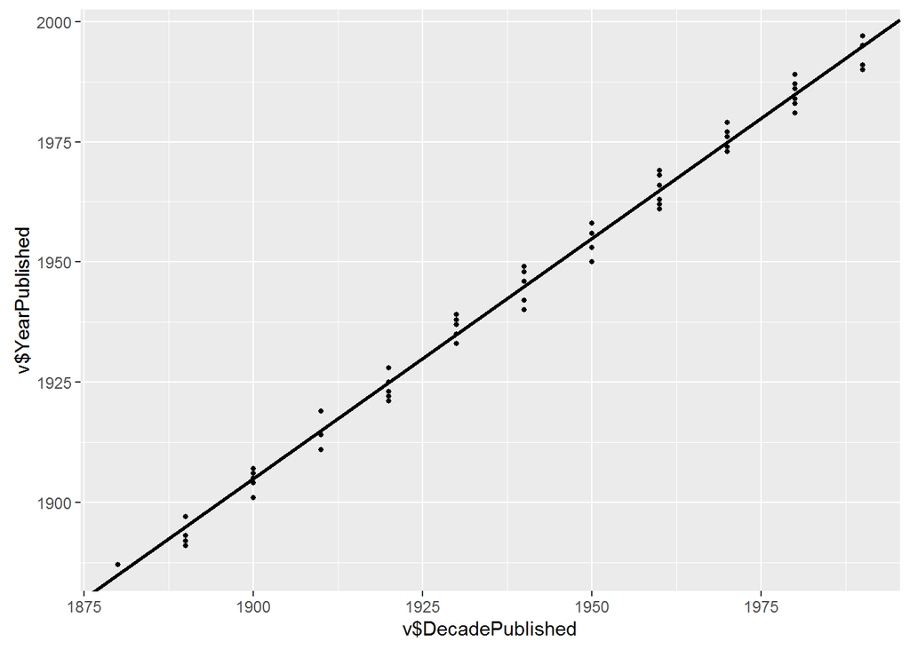

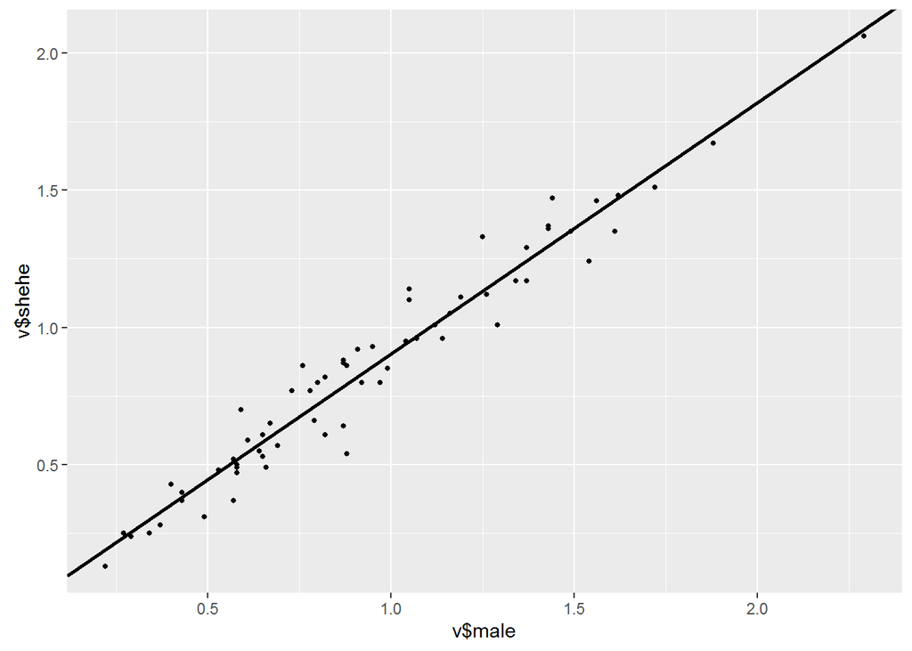

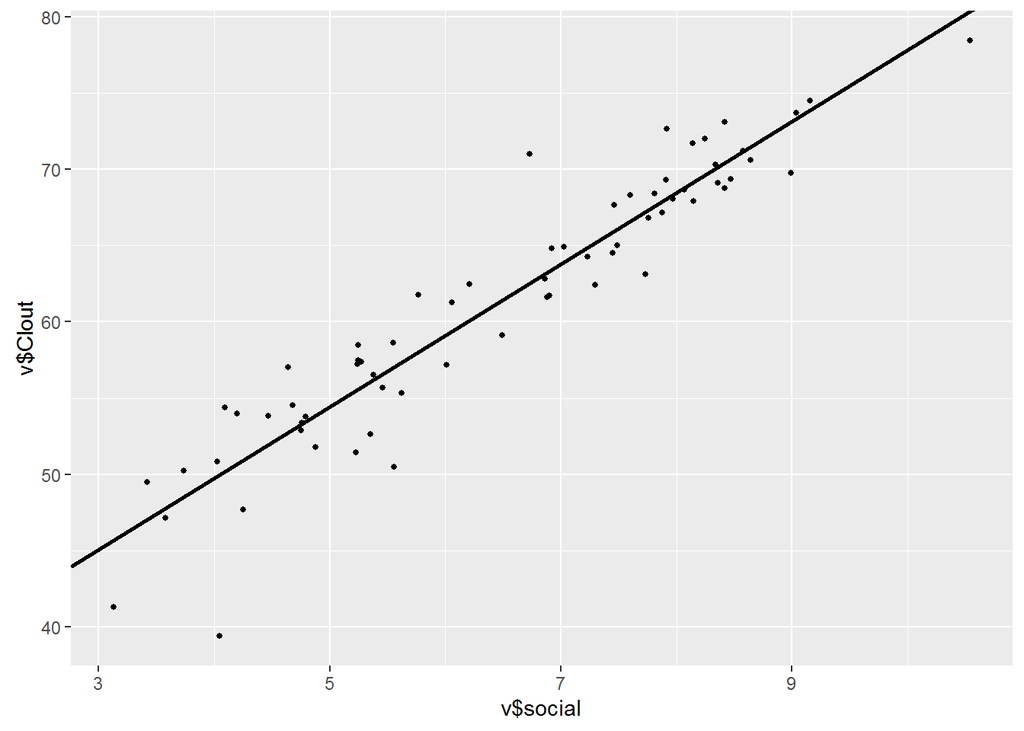

### Describe 2 predictions you might be able to make about the use of language in psychology textbooks over the next decade

This question is a bit subjective because the column names are not very clear what they mean so we have to take some assumptions here. In this example, let’s use three variables:

- DecadePublished
- Anger
- Sad

It would be better if we had variable that classified these book titles by subject, so it would be possible to try to predict the usage of these words only in Psychology books. Here, to linear models are going to be run: (DecadePublished ~ Anger) and (DecadePublished ~ Sad). The results will be evaulated based on what has happened to the use of the two words (sad and Anger, closely related to psychology subject) related to the time, and assuming the same trend will happen with Psychology books.

```
##
## Call:
## lm(formula = v$DecadePublished ~ v$anger)
##
## Residuals:
##    Min     1Q Median     3Q    Max
## -45.00 -17.28  -1.45  15.97  55.32
##
## Coefficients:
##             Estimate Std. Error t value Pr(>|t|)
## (Intercept) 1880.052      7.019 267.860  < 2e-16 ***
## v$anger      182.796     19.908   9.182 2.72e-13 ***
## ---
## Signif. codes:  0 '***' 0.001 '**' 0.01 '*' 0.05 '.' 0.1 ' ' 1
##
## Residual standard error: 21.27 on 64 degrees of freedom
## Multiple R-squared:  0.5685, Adjusted R-squared:  0.5617
## F-statistic: 84.31 on 1 and 64 DF,  p-value: 2.722e-13
```

```
##
## Call:
## lm(formula = v$DecadePublished ~ v$sad)
##
## Residuals:
##     Min      1Q  Median      3Q     Max
## -51.349 -23.261   6.261  20.743  54.268
##
## Coefficients:
##             Estimate Std. Error t value Pr(>|t|)
## (Intercept)  1870.00      14.24 131.283  < 2e-16 ***
## v$sad         219.12      43.41   5.047 3.96e-06 ***
## ---
## Signif. codes:  0 '***' 0.001 '**' 0.01 '*' 0.05 '.' 0.1 ' ' 1
##
## Residual standard error: 27.38 on 64 degrees of freedom
## Multiple R-squared:  0.2847, Adjusted R-squared:  0.2735
## F-statistic: 25.48 on 1 and 64 DF,  p-value: 3.962e-06
```

Since the slope of of both words seems to be positive and the p-value significantly less than 0.05, one could expect that the use of both words in literature titles are going to increase.

### Are there any multiply correlated columns in the dataset - where 3 or even 4 columns track together with a strong correlation?

```r
summary(lm(v$WC ~ v$Sixltr +v$function. + v$ppron))
```

```
##
## Call:
## lm(formula = v$WC ~ v$Sixltr + v$function. + v$ppron)
##
## Residuals:
##     Min      1Q  Median      3Q     Max
## -117001  -40252   -5870   33665  160907
##
## Coefficients:
##             Estimate Std. Error t value Pr(>|t|)
## (Intercept)  1354711     238190   5.688 3.73e-07 ***
## v$Sixltr       -9194       4291  -2.142  0.03609 *
## v$function.   -20458       3069  -6.666 8.11e-09 ***
## v$ppron        26111       9199   2.838  0.00612 **
## ---
## Signif. codes:  0 '***' 0.001 '**' 0.01 '*' 0.05 '.' 0.1 ' ' 1
##
## Residual standard error: 62980 on 62 degrees of freedom
## Multiple R-squared:  0.4881, Adjusted R-squared:  0.4633
## F-statistic: 19.71 on 3 and 62 DF,  p-value: 4.355e-09
```